# R Notebook

```r
library(jsonlite)
library(tidyverse)
library(caret)
library(lubridate)
```

```r
load_data <- function(){
    train_df <- read.csv("ProjectData/train.csv",stringsAsFactors = FALSE , colClasses = ("fullVisitorId" = "character"))
    test_df <- read.csv("ProjectData/test.csv", stringsAsFactors = FALSE,colClasses = ("fullVisitorId" = "character"))

    #Extract data from the json columns in TRAIN
    device_json_df <- paste("[", paste(train_df$device, collapse = ","), "]") %>%
                        fromJSON(flatten = T)

    geo_network_json_df <- paste("[", paste(train_df$geoNetwork, collapse = ","), "]") %>%
                        fromJSON(flatten = T)

    total_json_df <- paste("[", paste(train_df$totals, collapse = ","), "]") %>%
                        fromJSON(flatten = T)

    traffic_json_df <- paste("[", paste(train_df$trafficSource, collapse = ","), "]") %>%
                          fromJSON(flatten = T)

    train_df <- cbind(train_df,device_json_df,geo_network_json_df,total_json_df,traffic_json_df)


    #Drop the json columns
    train_df <- select(train_df,  -one_of(c("device","geoNetwork","totals","trafficSource")))

    #Extract data from the json columns in TEST
    device_json_df <- paste("[", paste(test_df$device, collapse = ","), "]") %>%
      fromJSON(flatten = T)

    geo_network_json_df <- paste("[", paste(test_df$geoNetwork, collapse = ","), "]") %>%
      fromJSON(flatten = T)

    total_json_df <- paste("[", paste(test_df$totals, collapse = ","), "]") %>%
      fromJSON(flatten = T)

    traffic_json_df <- paste("[", paste(test_df$trafficSource, collapse = ","), "]") %>%
      fromJSON(flatten = T)

    test_df <- cbind(test_df,device_json_df,geo_network_json_df,total_json_df,traffic_json_df)

    test_df <- select(test_df,  -one_of(c("device","geoNetwork","totals","trafficSource")))

    rm(device_json_df,geo_network_json_df,total_json_df,traffic_json_df)

    saveRDS(train_df,"ProjectData/train_df")
    saveRDS(test_df,"ProjectData/test_df")

}
```

```r
if (!file.exists("ProjectData/train_df" ) | !file.exists("ProjectData/test_df" )){
  cat("Loading Saved Data... \n")
    train_df <-  readRDS("ProjectData/train_df" )
    test_df <- readRDS("ProjectData/test_df")
} else {
  cat("Preparing and Loading Data...")
    load_data()
    train_df <-  readRDS("ProjectData/train_df" )
    test_df <- readRDS("ProjectData/test_df")
}
```

```
Preparing and Loading Data...
```

Structure of Train Dataset:

```r
glimpse(train_df)
```

```
Observations: 903,653
Variables: 55
$ channelGrouping                     <chr> "Organic Search", "Organic Search", "Organic Sear...
$ date                                <chr> "20160902", "20160902", "20160902", "20160902", "...
$ fullVisitorId                       <chr> "1131660440785968503", "377306020877927890", "389...
$ sessionId                           <chr> "1131660440785968503_1472830385", "37730602087792...
$ socialEngagementType                <chr> "Not Socially Engaged", "Not Socially Engaged", "...
$ visitId                             <chr> "1472830385", "1472880147", "1472865386", "147288...
$ visitNumber                         <chr> "1", "1", "1", "1", "2", "1", "1", "1", "1", "1",...
$ visitStartTime                      <chr> "1472830385", "1472880147", "1472865386", "147288...
$ browser                             <chr> "Chrome", "Firefox", "Chrome", "UC Browser", "Chr...
$ browserVersion                      <chr> "not available in demo dataset", "not available i...
$ browserSize                         <chr> "not available in demo dataset", "not available i...
$ operatingSystem                     <chr> "Windows", "Macintosh", "Windows", "Linux", "Andr...
$ operatingSystemVersion              <chr> "not available in demo dataset", "not available i...
```

[output cut: 42 more lines]

```r
colSums(is.na(train_df))
```

```r
unique_length <- function (x){
  #Function to calculate no. of unique values in a variable
  length(unique(x))
}
```

No of unique elements in each column of Train

```r
sapply(train_df, unique_length) %>% as.data.frame()
```

|  | . |
| --- | --- |
| channelGrouping | 8 |
| date | 366 |
| fullVisitorId | 714167 |
| sessionId | 902755 |
| socialEngagementType | 1 |
| visitId | 886303 |
| visitNumber | 384 |
| visitStartTime | 887159 |
| browser | 54 |
| browserVersion | 1 |

[output cut: 45 more lines]

Transaction Revenue is the target column. Or rather the natural log of the transaction Revenue

There are multiple columns in the train set which have only one unique value. We can remove these columns.

```r
remove_columns <- function(df,cols_to_remove){
  #Function to check existence of column and if exists, remove it
  df[,cols_to_remove] <- NULL
  return(df)
}
```

Identify all features with just one unique value

```r
cols_to_remove <- data.frame(Feature = names(sapply(train_df, unique_length)),  Freq=data.frame(sapply(train_df, unique_length))[,1])  %>%
  filter(Freq==1) %>%
  select(Feature) %>%
  .$Feature %>%
  as.character()
```

```r
train_df <- remove_columns(train_df,cols_to_remove = cols_to_remove)
```

```r
nearZeroVarCols <- names(train_df[,nearZeroVar(train_df)])
nearZeroVarCols
```

```
 [1] "bounces"                        "newVisits"
 [3] "campaign"                       "keyword"
 [5] "isTrueDirect"                   "campaignCode"
 [7] "adwordsClickInfo.page"          "adwordsClickInfo.slot"
 [9] "adwordsClickInfo.adNetworkType" "adwordsClickInfo.isVideoAd"
```

```r
sapply(train_df[,nearZeroVarCols], unique_length) %>% as.data.frame()
```

|  | . |
| --- | --- |
| bounces | 2 |
| newVisits | 2 |
| campaign | 10 |
| keyword | 3660 |
| isTrueDirect | 2 |
| campaignCode | 2 |
| adwordsClickInfo.page | 9 |
| adwordsClickInfo.slot | 3 |
| adwordsClickInfo.adNetworkType | 3 |
| adwordsClickInfo.isVideoAd | 2 |

```r
colSums(is.na(train_df))
```

```
               channelGrouping                           date                  fullVisitorId
                             0                              0                              0
                     sessionId                        visitId                    visitNumber
                             0                              0                              0
                visitStartTime                        browser                operatingSystem
                             0                              0                              0
                      isMobile                 deviceCategory                      continent
                             0                              0                              0
                  subContinent                        country                         region
                             0                              0                              0
                         metro                           city                  networkDomain
                             0                              0                              0
                          hits                      pageviews                        bounces
                             0                            100                         453023
                     newVisits             transactionRevenue                       campaign
                        200593                         892138                              0
                        source                         medium                        keyword
                             0                              0                         502929
                  isTrueDirect                   referralPath                      adContent
                        629648                         572712                         892707
                  campaignCode          adwordsClickInfo.page          adwordsClickInfo.slot
                        903652                         882193                         882193
        adwordsClickInfo.gclId adwordsClickInfo.adNetworkType     adwordsClickInfo.isVideoAd
                        882092                         882193                         882193
```

```r
glimpse(train_df)
```

```
Observations: 903,653
Variables: 36
$ channelGrouping                <chr> "Organic Search", "Organic Search", "Organic Search", ...
$ date                           <chr> "20160902", "20160902", "20160902", "20160902", "20160...
$ fullVisitorId                  <chr> "1131660440785968503", "377306020877927890", "38955462...
$ sessionId                      <chr> "1131660440785968503_1472830385", "377306020877927890_...
$ visitId                        <chr> "1472830385", "1472880147", "1472865386", "1472881213"...
$ visitNumber                    <chr> "1", "1", "1", "1", "2", "1", "1", "1", "1", "1", "1",...
$ visitStartTime                 <chr> "1472830385", "1472880147", "1472865386", "1472881213"...
$ browser                        <chr> "Chrome", "Firefox", "Chrome", "UC Browser", "Chrome",...
$ operatingSystem                <chr> "Windows", "Macintosh", "Windows", "Linux", "Android",...
$ isMobile                       <lgl> FALSE, FALSE, FALSE, FALSE, TRUE, FALSE, FALSE, FALSE,...
$ deviceCategory                 <chr> "desktop", "desktop", "desktop", "desktop", "mobile", ...
$ continent                      <chr> "Asia", "Oceania", "Europe", "Asia", "Europe", "Europe...
$ subContinent                   <chr> "Western Asia", "Australasia", "Southern Europe", "Sou...
```

[output cut: 23 more lines]

##### ANanlyzing Transaction Revenue

First convert it into numeric

```r
train_df$transactionRevenue <- as.numeric(train_df$transactionRevenue)
```

Converting NAs in Transaction Revenues to 0

```r
train_df$transactionRevenue <- ifelse(is.na(train_df$transactionRevenue),0,train_df$transactionRevenue)
```

Add a REVENUE_GENERATED column to the data frame

```r
train_df$REVENUE_GENERATED = ifelse(train_df$transactionRevenue ==0 , FALSE, TRUE)
```

No. Of Transaction generating Revenue

```r
cat("No. of revenue generating transactions: ", nrow(train_df[train_df$REVENUE_GENERATED==TRUE,]))
```

```
No. of revenue generating transactions:  11515
```

```r
cat("\nNo. of non-revenue generating transactions: ", nrow(train_df[train_df$REVENUE_GENERATED==FALSE,]))
```

```
No. of non-revenue generating transactions:  892138
```

```r
cat("\nProportion of revenue generating transactions: ",nrow(train_df[train_df$REVENUE_GENERATED==TRUE,]) / nrow(train_df) *100 ,"%")
```

```
Proportion of revenue generating transactions:  1.274272 %
```

```r
train_df %>%
  group_by(fullVisitorId) %>%
  mutate(sum_Revenue = sum(ifelse(is.na(transactionRevenue),0,transactionRevenue))) %>%
  select(fullVisitorId,sum_Revenue) %>%
  filter(sum_Revenue==0) %>%
  nrow
```

```
[1] 867543
```

###### Channel Grouping

```r
unique(train_df$channelGrouping)
```

```
[1] "Organic Search" "Referral"       "Paid Search"    "Affiliates"     "Direct"
[6] "Display"        "Social"         "(Other)"
```

PErcent Distribution of channel grouping

```r
prop.table(table(train_df$channelGrouping, useNA = "ifany") ) *100
```

```
       (Other)     Affiliates         Direct        Display Organic Search    Paid Search
    0.01327943     1.81518791    15.82753557     0.69296511    42.22428299     2.80262446
      Referral         Social
   11.60157715    25.02254737
```

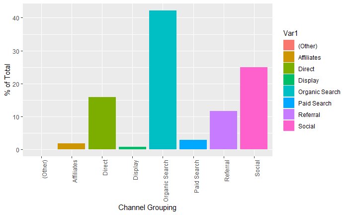

```r
prop.table(table(train_df$channelGrouping, useNA = "ifany" )) %>%
  as.data.frame() %>%
  ggplot() + geom_bar(aes(x=Var1, y =Freq*100,fill=Var1 ), stat="identity") + theme(axis.text.x = element_text(angle = 90, hjust = 1)) +xlab("Channel Grouping") + ylab("% of Total")
```

Percent distribution of Revenue Generating Transaction for Channel Grouping

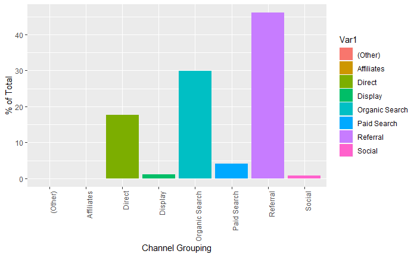

```r
prop.table(table(train_df$channelGrouping[train_df$REVENUE_GENERATED == TRUE], useNA = "ifany" )) %>%
  as.data.frame() %>%
  ggplot() + geom_bar(aes(x=Var1, y =Freq*100,fill=Var1 ), stat="identity") + theme(axis.text.x = element_text(angle = 90, hjust = 1)) +xlab("Channel Grouping") + ylab("% of Total")
```

For transactions generating revenue, these are the most popular channels:  
* Referral (~50% revenue generating transactions )  
* Organic Search (~30%)  
* Direct (~17%)

So while Organic Search is the most common channel, revenue generating transactions come mostly from the Referrals.

##### Checking Date

```r
class(train_df$date)
```

```
[1] "character"
```

```r
train_df$date[1:6]
```

```
[1] "20160902" "20160902" "20160902" "20160902" "20160902" "20160902"
```

```r
train_df$date <- ymd(train_df$date)
range(train_df$date)
```

```
[1] "2016-08-01" "2017-08-01"
```

```r
test_df$date <- ymd(test_df$date)
range(test_df$date)
```

```
[1] "2017-08-02" "2018-04-30"
```

Checking distribution of transactions month wise

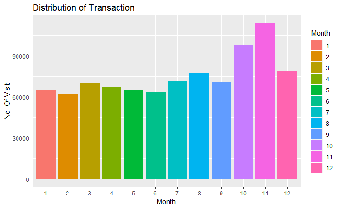

```r
train_df %>%
  group_by(Month = as.factor(month(date))) %>%
  summarize( Count =n()) %>%
  select(Month, Count) %>%
  ggplot() + geom_bar(aes(x= Month, y = Count, fill = Month), stat= "identity") + ylab("No. Of Visit") + xlab("Month") + labs(title = "Distribution of Transaction")
```

```r
NA
```

Year ending months October, November and December have highest transactions

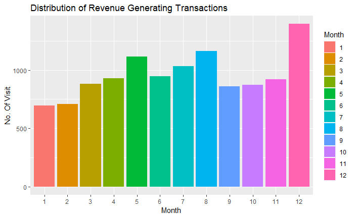

```r
train_df %>%
  filter(REVENUE_GENERATED) %>%
  group_by(Month = as.factor(month(date))) %>%
  summarize( Count =n()) %>%
  select(Month, Count)  %>%
  ggplot() + geom_bar(aes(x= Month, y = Count, fill = Month), stat= "identity") + ylab("No. Of Visit") + xlab("Month") + labs(title = "Distribution of Revenue Generating Transactions")
```

December has the highest number of revenue generating transactions.

It will be interesting to see what proportion of transactions each month are revenue generating

```r
train_df %>%
  mutate(Month = as.factor(month(date))) %>%
  group_by(Month) %>%
  #summarize() %>%
  summarize(Month_Transaction = n(),Revenue_Transaction = sum(REVENUE_GENERATED), Proportion = Revenue_Transaction/Month_Transaction*100) %>%
  select (Month,Month_Transaction,Revenue_Transaction,Proportion)
```

| Month | Month_Transaction | Revenue_Transaction | Proportion |
| --- | --- | --- | --- |
| 1 | 64694 | 697 | 1.0773797 |
| 2 | 62192 | 708 | 1.1384101 |
| 3 | 69931 | 883 | 1.2626732 |
| 4 | 67126 | 928 | 1.3824747 |
| 5 | 65371 | 1115 | 1.7056493 |
| 6 | 63578 | 946 | 1.4879361 |
| 7 | 71812 | 1031 | 1.4356932 |
| 8 | 77315 | 1162 | 1.5029425 |
| 9 | 71032 | 859 | 1.2093141 |
| 10 | 97506 | 872 | 0.8943039 |

[output cut: 2 more lines]

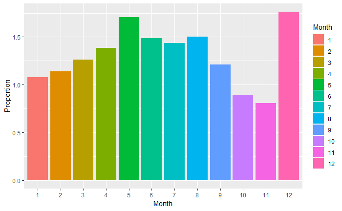

May and December have the highest proportion of transactions which are revenue generating

#####Analyzing visit number Convert visit number to numeric

```r
train_df$visitNumber <- as.numeric(train_df$visitNumber)
```

```r
cat("Visist Number has ", length(unique(train_df$visitNumber)) ," unique values")
```

```
Visist Number has  384  unique values
```

```
Ignoring unknown parameters: binwidth, bins, pad
```

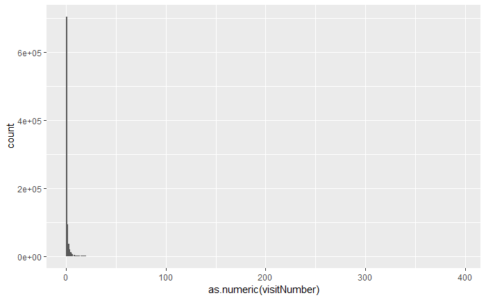

```r
ggplot(train_df) + geom_histogram(aes(x= as.numeric(visitNumber)), stat="count", binwidth = 40)
```

Visit Numbers are mostly very small

```r
quantile(train_df$visitNumber)
```

```
  0%  25%  50%  75% 100%
   1    1    1    1  395
```

[output not shown]

[output cut: 20 more lines]

Does probability of revenue increase with larger visit numbers?

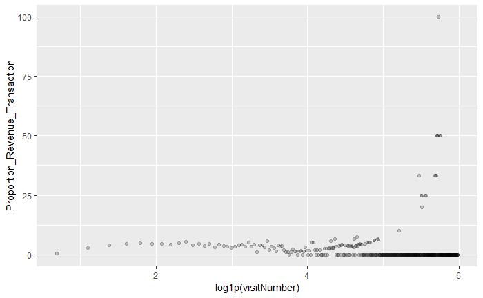

```r
train_df %>%
  group_by(visitNumber) %>%
  summarize(Revenue_Transactions = sum(REVENUE_GENERATED==TRUE),
            NonRevenue_Transactions = sum(REVENUE_GENERATED==FALSE),
            Total_Transactions = Revenue_Transactions + NonRevenue_Transactions,
            Proportion_Revenue_Transaction = (Revenue_Transactions / Total_Transactions) * 100) %>%
            #filter(Proportion_Revenue_Transaction !=0) %>%
            ggplot() + geom_point(aes(x = log1p(visitNumber) , y = Proportion_Revenue_Transaction),alpha =0.2)
```

The proportion of Revenue transaction increases till about visit number 6.3890561 and then slowly tapers out till about 53.59815 . Beyond 53.59815 there are ocassional visit numbers which have high proportion of revenue transactions, but since they are few and far between, they will hardly constitute a trend.

##### Analyzing Visit Start Time

```r
train_df[1:5,"visitStartTime1"]
```

```
[1] NA NA NA NA NA
```